# Ford GoBike System Data

## Preliminary Wrangling

> Ford GoBike System Data includes information about individual rides made in a bike-sharing system covering the greater San Francisco Bay area.

```python
# import all packages and set plots to be embedded inline
import numpy as np
import pandas as pd
import matplotlib.pyplot as plt
import seaborn as sb

%matplotlib inline
```

> Load dataset. Try and motivate your exploration goals through this section.

```python
# Read and show data set
df = pd.read_csv('201902-fordgobike-tripdata.csv')
df.head()
```

|  | duration_sec | start_time | end_time | start_station_id | start_station_name | start_station_latitude | start_station_longitude | end_station_id | end_station_name | end_station_latitude | end_station_longitude | bike_id | user_type | member_birth_year | member_gender | bike_share_for_all_trip |
| --- | --- | --- | --- | --- | --- | --- | --- | --- | --- | --- | --- | --- | --- | --- | --- | --- |
| 0 | 52185 | 2019-02-28 17:32:10.1450 | 2019-03-01 08:01:55.9750 | 21.0 | Montgomery St BART Station (Market St at 2nd St) | 37.789625 | -122.400811 | 13.0 | Commercial St at Montgomery St | 37.794231 | -122.402923 | 4902 | Customer | 1984.0 | Male | No |
| 1 | 42521 | 2019-02-28 18:53:21.7890 | 2019-03-01 06:42:03.0560 | 23.0 | The Embarcadero at Steuart St | 37.791464 | -122.391034 | 81.0 | Berry St at 4th St | 37.775880 | -122.393170 | 2535 | Customer | NaN | NaN | No |
| 2 | 61854 | 2019-02-28 12:13:13.2180 | 2019-03-01 05:24:08.1460 | 86.0 | Market St at Dolores St | 37.769305 | -122.426826 | 3.0 | Powell St BART Station (Market St at 4th St) | 37.786375 | -122.404904 | 5905 | Customer | 1972.0 | Male | No |
| 3 | 36490 | 2019-02-28 17:54:26.0100 | 2019-03-01 04:02:36.8420 | 375.0 | Grove St at Masonic Ave | 37.774836 | -122.446546 | 70.0 | Central Ave at Fell St | 37.773311 | -122.444293 | 6638 | Subscriber | 1989.0 | Other | No |
| 4 | 1585 | 2019-02-28 23:54:18.5490 | 2019-03-01 00:20:44.0740 | 7.0 | Frank H Ogawa Plaza | 37.804562 | -122.271738 | 222.0 | 10th Ave at E 15th St | 37.792714 | -122.248780 | 4898 | Subscriber | 1974.0 | Male | Yes |

```python
#Check data types for each columns
df.dtypes
```

```
duration_sec                 int64
start_time                  object
end_time                    object
start_station_id           float64
start_station_name          object
start_station_latitude     float64
start_station_longitude    float64
end_station_id             float64
end_station_name            object
end_station_latitude       float64
end_station_longitude      float64
bike_id                      int64
user_type                   object
member_birth_year          float64
member_gender               object
bike_share_for_all_trip     object
dtype: object
```

```python
# Show how many columns and rows in the dataset
df.shape
```

```
(183412, 16)
```

```python
# Show values od user_type column
df['user_type'].value_counts()
```

```
Subscriber    163544
Customer       19868
Name: user_type, dtype: int64
```

```python
#Check if there is a null values
df.isnull().sum()
```

```
duration_sec                  0
start_time                    0
end_time                      0
start_station_id            197
start_station_name          197
start_station_latitude        0
start_station_longitude       0
end_station_id              197
end_station_name            197
end_station_latitude          0
end_station_longitude         0
bike_id                       0
user_type                     0
member_birth_year          8265
member_gender              8265
bike_share_for_all_trip       0
dtype: int64
```

```python
#Check if there is a duplicated
df.duplicated().sum()
```

```
0
```

```python
# Taking copy of the data fame before doing any change
df_clean = df.copy()
```

```python
# Show dtypes of each column
df_clean.dtypes
```

```
duration_sec                 int64
start_time                  object
end_time                    object
start_station_id           float64
start_station_name          object
start_station_latitude     float64
start_station_longitude    float64
end_station_id             float64
end_station_name            object
end_station_latitude       float64
end_station_longitude      float64
bike_id                      int64
user_type                   object
member_birth_year          float64
member_gender               object
bike_share_for_all_trip     object
dtype: object
```

### What is the structure of your dataset?

The data structured has 183412 of records with 16 features. The dataset contains: duration, start time, end time, start station id, start station name,end station id, end station name, user type ( Subscriber or Customer), member birth year, member gender, bike share for all trip.

### What is/are the main feature(s) of interest in your dataset?

- What is the average duration of the trip?
- Average trip times by gender?
- What is the dates we have more users of bike ride?
- Who are the Ford Go Bike customers?

### What features in the dataset do you think will help support your investigation into your feature(s) of interest?

Tha main features of interest are:

- User type.
- Trip duration.
- Satrt date .
- Member gender.

### Data Wrangling

Before starting exploration I want to do some wrangling process contain:

- Change start_time and end_time columns dtype.
- Delete bike share for all trip column.
- Delete values where the station id is null.
- Convert the end and start station id to int.
- Calculate age for each member by extacting it from date of birth

```python
# Define: Change start_time and end_time columns dtype

# Code
dtype= {'start_time': 'datetime64',
        'end_time': 'datetime64'}

df_clean = df_clean.astype(dtype)

# Test
df_clean.info()
```

```
<class 'pandas.core.frame.DataFrame'>
RangeIndex: 183412 entries, 0 to 183411
Data columns (total 16 columns):
 #   Column                   Non-Null Count   Dtype
---  ------                   --------------   -----
 0   duration_sec             183412 non-null  int64
 1   start_time               183412 non-null  datetime64[ns]
 2   end_time                 183412 non-null  datetime64[ns]
 3   start_station_id         183215 non-null  float64
 4   start_station_name       183215 non-null  object
 5   start_station_latitude   183412 non-null  float64
 6   start_station_longitude  183412 non-null  float64
 7   end_station_id           183215 non-null  float64
 8   end_station_name         183215 non-null  object
 9   end_station_latitude     183412 non-null  float64
 10  end_station_longitude    183412 non-null  float64
 11  bike_id                  183412 non-null  int64
 12  user_type                183412 non-null  object
 13  member_birth_year        175147 non-null  float64
 14  member_gender            175147 non-null  object
 15  bike_share_for_all_trip  183412 non-null  object
dtypes: datetime64[ns](2), float64(7), int64(2), object(5)
memory usage: 22.4+ MB
```

```python
# Define: Delete bike share for all trip column

# Code
df_clean.drop(columns='bike_share_for_all_trip',inplace=True,axis=1)

# Test
df_clean.info()
```

```
<class 'pandas.core.frame.DataFrame'>
RangeIndex: 183412 entries, 0 to 183411
Data columns (total 15 columns):
 #   Column                   Non-Null Count   Dtype
---  ------                   --------------   -----
 0   duration_sec             183412 non-null  int64
 1   start_time               183412 non-null  datetime64[ns]
 2   end_time                 183412 non-null  datetime64[ns]
 3   start_station_id         183215 non-null  float64
 4   start_station_name       183215 non-null  object
 5   start_station_latitude   183412 non-null  float64
 6   start_station_longitude  183412 non-null  float64
 7   end_station_id           183215 non-null  float64
 8   end_station_name         183215 non-null  object
 9   end_station_latitude     183412 non-null  float64
 10  end_station_longitude    183412 non-null  float64
 11  bike_id                  183412 non-null  int64
 12  user_type                183412 non-null  object
 13  member_birth_year        175147 non-null  float64
 14  member_gender            175147 non-null  object
dtypes: datetime64[ns](2), float64(7), int64(2), object(4)
memory usage: 21.0+ MB
```

```python
# Define: Delete values where the station id is null.

# Code
df_clean[df_clean['start_station_id'].isna()]
df_clean.dropna(subset=['start_station_id'],inplace=True)

# Test
df_clean.info()
```

```
<class 'pandas.core.frame.DataFrame'>
Int64Index: 183215 entries, 0 to 183411
Data columns (total 15 columns):
 #   Column                   Non-Null Count   Dtype
---  ------                   --------------   -----
 0   duration_sec             183215 non-null  int64
 1   start_time               183215 non-null  datetime64[ns]
 2   end_time                 183215 non-null  datetime64[ns]
 3   start_station_id         183215 non-null  float64
 4   start_station_name       183215 non-null  object
 5   start_station_latitude   183215 non-null  float64
 6   start_station_longitude  183215 non-null  float64
 7   end_station_id           183215 non-null  float64
 8   end_station_name         183215 non-null  object
 9   end_station_latitude     183215 non-null  float64
 10  end_station_longitude    183215 non-null  float64
 11  bike_id                  183215 non-null  int64
 12  user_type                183215 non-null  object
 13  member_birth_year        174952 non-null  float64
 14  member_gender            174952 non-null  object
dtypes: datetime64[ns](2), float64(7), int64(2), object(4)
memory usage: 22.4+ MB
```

```python
# Define: Convert the end and start station id to int.

# Code
df_clean['start_station_id']=df_clean['start_station_id'].astype(int)
df_clean['end_station_id']=df_clean['end_station_id'].astype(int)

# Test
df_clean.info()
```

```
<class 'pandas.core.frame.DataFrame'>
Int64Index: 183215 entries, 0 to 183411
Data columns (total 15 columns):
 #   Column                   Non-Null Count   Dtype
---  ------                   --------------   -----
 0   duration_sec             183215 non-null  int64
 1   start_time               183215 non-null  datetime64[ns]
 2   end_time                 183215 non-null  datetime64[ns]
 3   start_station_id         183215 non-null  int64
 4   start_station_name       183215 non-null  object
 5   start_station_latitude   183215 non-null  float64
 6   start_station_longitude  183215 non-null  float64
 7   end_station_id           183215 non-null  int64
 8   end_station_name         183215 non-null  object
 9   end_station_latitude     183215 non-null  float64
 10  end_station_longitude    183215 non-null  float64
 11  bike_id                  183215 non-null  int64
 12  user_type                183215 non-null  object
 13  member_birth_year        174952 non-null  float64
 14  member_gender            174952 non-null  object
dtypes: datetime64[ns](2), float64(5), int64(4), object(4)
memory usage: 22.4+ MB
```

```python
# Define: calculate age of the members by extacting it from member_birth_year

# code
df_clean['member_age'] = 2019 - df_clean['member_birth_year']

# test
df_clean.head()
```

|  | duration_sec | start_time | end_time | start_station_id | start_station_name | start_station_latitude | start_station_longitude | end_station_id | end_station_name | end_station_latitude | end_station_longitude | bike_id | user_type | member_birth_year | member_gender | member_age |
| --- | --- | --- | --- | --- | --- | --- | --- | --- | --- | --- | --- | --- | --- | --- | --- | --- |
| 0 | 52185 | 2019-02-28 17:32:10.145 | 2019-03-01 08:01:55.975 | 21 | Montgomery St BART Station (Market St at 2nd St) | 37.789625 | -122.400811 | 13 | Commercial St at Montgomery St | 37.794231 | -122.402923 | 4902 | Customer | 1984.0 | Male | 35.0 |
| 1 | 42521 | 2019-02-28 18:53:21.789 | 2019-03-01 06:42:03.056 | 23 | The Embarcadero at Steuart St | 37.791464 | -122.391034 | 81 | Berry St at 4th St | 37.775880 | -122.393170 | 2535 | Customer | NaN | NaN | NaN |
| 2 | 61854 | 2019-02-28 12:13:13.218 | 2019-03-01 05:24:08.146 | 86 | Market St at Dolores St | 37.769305 | -122.426826 | 3 | Powell St BART Station (Market St at 4th St) | 37.786375 | -122.404904 | 5905 | Customer | 1972.0 | Male | 47.0 |
| 3 | 36490 | 2019-02-28 17:54:26.010 | 2019-03-01 04:02:36.842 | 375 | Grove St at Masonic Ave | 37.774836 | -122.446546 | 70 | Central Ave at Fell St | 37.773311 | -122.444293 | 6638 | Subscriber | 1989.0 | Other | 30.0 |
| 4 | 1585 | 2019-02-28 23:54:18.549 | 2019-03-01 00:20:44.074 | 7 | Frank H Ogawa Plaza | 37.804562 | -122.271738 | 222 | 10th Ave at E 15th St | 37.792714 | -122.248780 | 4898 | Subscriber | 1974.0 | Male | 45.0 |

```python
df_clean.info()
```

```
<class 'pandas.core.frame.DataFrame'>
Int64Index: 183215 entries, 0 to 183411
Data columns (total 16 columns):
 #   Column                   Non-Null Count   Dtype
---  ------                   --------------   -----
 0   duration_sec             183215 non-null  int64
 1   start_time               183215 non-null  datetime64[ns]
 2   end_time                 183215 non-null  datetime64[ns]
 3   start_station_id         183215 non-null  int64
 4   start_station_name       183215 non-null  object
 5   start_station_latitude   183215 non-null  float64
 6   start_station_longitude  183215 non-null  float64
 7   end_station_id           183215 non-null  int64
 8   end_station_name         183215 non-null  object
 9   end_station_latitude     183215 non-null  float64
 10  end_station_longitude    183215 non-null  float64
 11  bike_id                  183215 non-null  int64
 12  user_type                183215 non-null  object
 13  member_birth_year        174952 non-null  float64
 14  member_gender            174952 non-null  object
 15  member_age               174952 non-null  float64
dtypes: datetime64[ns](2), float64(6), int64(4), object(4)
memory usage: 23.8+ MB
```

## Univariate Exploration

> In this section, investigate distributions of individual variables. If you see unusual points or outliers, take a deeper look to clean things up and prepare yourself to look at relationships between variables.

What is the average duration of the trip?

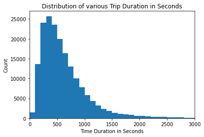

```python
# Here we plot the histogram distribution of trip durations.

bins = np.arange(0, df_clean['duration_sec'].max() + 100 , 100)
plt.hist(data = df_clean , x = 'duration_sec' , bins = bins)
plt.xlim(0,3000)
plt.title('Distribution of various Trip Duration in Seconds')
plt.xlabel('Time Duration in Seconds')
plt.ylabel('Count')
```

As we can see from the graph above that the the plot is in Right-Skewed. I'll converting the seconds into minutes for better understanding of the graph as below.

```python
# Converting the seconds into minutes for better understanding of the graph.
df_clean['duration_min'] = df_clean['duration_sec'] / 60
```

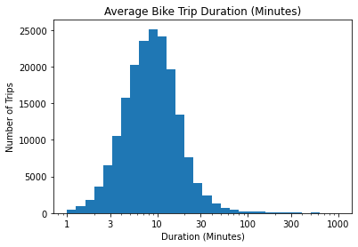

```python
#Log transforming to better understand the data
bins = 10**np.arange(0 , 3 + 0.1 , 0.1)
ticks =  [ 1 , 3, 10, 30, 100, 300, 1000]
labels = ['{}'.format(v) for v in ticks]
plt.hist(data = df_clean , x = 'duration_min' , bins = bins);
plt.xscale('log');
plt.xticks(ticks,labels);
plt.xlabel('Duration (Minutes)');
plt.title('Average Bike Trip Duration (Minutes)');
plt.ylabel('Number of Trips');
```

As ready to see from the over plot, users have a propensity towards utilizing the bikes for a short-time length trips with around 10 mins.

```python
# Create new column start_date
df_clean['start_date'] = pd.to_datetime(df_clean['start_time']).dt.date
```

What is the day has more users of bike ride?

```python
# create day column
df_clean['start_day'] = pd.DatetimeIndex(df_clean['start_date']).day_name()
```

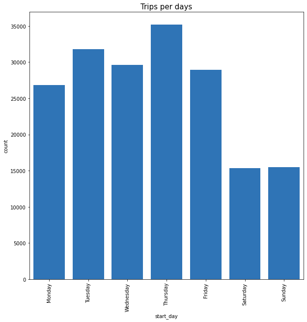

```python
# Show count plot to more understanding using days names to know which specific days has more.
orders = ['Monday','Tuesday','Wednesday','Thursday','Friday','Saturday','Sunday']
plt.figure(figsize=(10,10))
plt.xticks(rotation=90)
plt.title('Trips per days', size= 15)
sb.countplot(data= df_clean, x = 'start_day', color= '#1874CD', order=orders);
```

As ready to see from the over chart appears that the working days there are more trips than the end of the week. Usually too appears that the most elevated trips would be amid Thursday at that point Tuesday with more than 3000 check ride trips. Too, the end of the week Saturday and Sunday has the least that clarification to require rest and unwinding.

What is the average bike trip by Subscriber and Customer?

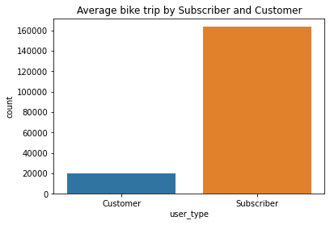

```python
# Show count of subcriber vis customer

sb.countplot(data=df_clean,x='user_type')
plt.title('Average bike trip by Subscriber and Customer');
```

#### Who are the Ford Go Bike customers ?

What is the distubution of member gender ?

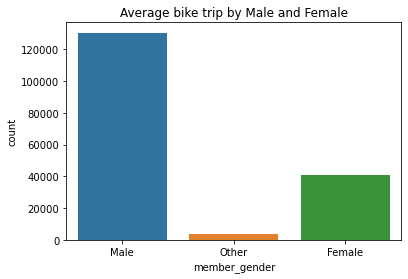

```python
# count plot member_gender column
sb.countplot(data = df_clean, x = 'member_gender');
plt.title('Average bike trip by Male and Female');
```

What is the distubtion of member age?

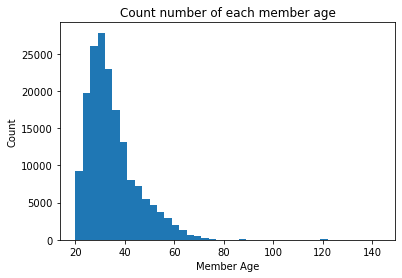

```python
binsize = 3
bins = np.arange(20, df_clean['member_age'].max()+binsize, binsize)
plt.hist(data = df_clean, x = 'member_age', bins = bins)
plt.xlabel('Member Age');
plt.ylabel('Count');
plt.title('Count number of each member age');
```

As we have see from the graph and expected when getting older usage rate decreases. As clear, in age 30 a lot of usage of ride bike than any other age.

So, now we know that the customers of Ford Go Bike they're aged in their '30s, and most of them are male.

### Discuss the distribution(s) of your variable(s) of interest. Were there any unusual points? Did you need to perform any transformations?

For better understanding of graph we make it in days as shown above we create new column (day) and taking days from start_time column.

### Of the features you investigated, were there any unusual distributions? Did you perform any operations on the data to tidy, adjust, or change the form of the data? If so, why did you do this?

As we see from above I did add some columns to explore more and visualize better.

## Bivariate Exploration

> In this section, investigate relationships between pairs of variables in your data.

### Ride duration during this month

What is the gender of user has more trip?

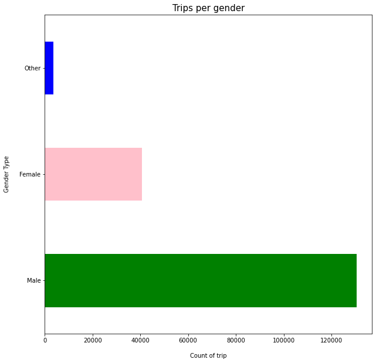

```python
# Show barh chart of users gender

color = ['green', 'pink', 'blue']

df_clean.member_gender.value_counts().plot(kind='barh', color=color, figsize=(10,10), fontsize=10)
plt.title('Trips per gender', size= 15)
plt.ylabel('Gender Type', labelpad=16)
plt.xlabel('Count of trip', labelpad=16)


plt.xticks(rotation=360)
```

As we expected from the barh chart above the male has more trip with more than 100000 count trip.

Investigate the relationship between duration bike ride time and user type.

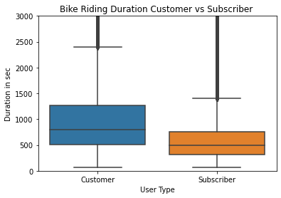

```python
# Show box plot to Investigate the relationship between duration bike ride time and user type.

sb.boxplot(data=df_clean, x='user_type', y='duration_sec')
plt.ylim(0,3000)
plt.title("Bike Riding Duration Customer vs Subscriber ")
plt.xlabel('User Type')
plt.ylabel('Duration in sec')
plt.show()
```

As we can see from the graph above the customer has more duration time than subscriber.

Investigate the relationship between start day and member gender with count.

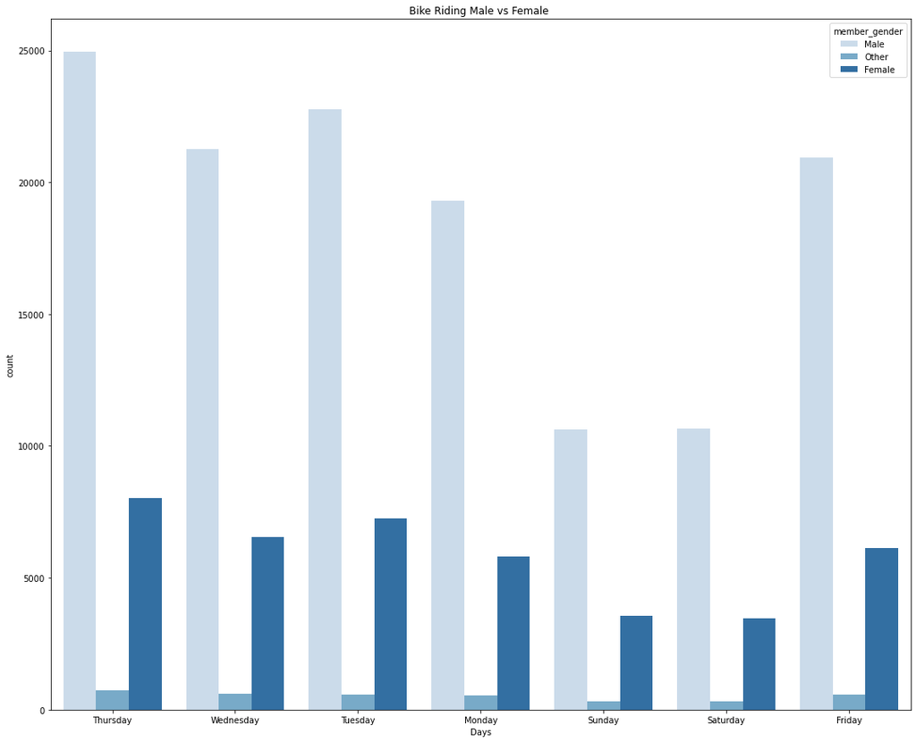

```python
# show countplot for member_gender and start_day
plt.figure(figsize = [40, 15]);

ax = plt.subplot(1, 2, 1);
plt.title("Bike Riding Male vs Female ")
sb.countplot(data = df_clean, x = 'start_day', hue = 'member_gender', palette = 'Blues');
plt.xlabel('Days')
```

As we ban see from graph the Thursday is the most day has trip count with male that more than 20000 trips and female with more than 5000 trips.

### Did you observe any interesting relationships between the other features (not the main feature(s) of interest)?

The number of trips is moo amid ends of the week which proposes that clients tend to either remain domestic or select another frame of transportation amid ends of the week.

## Multivariate Exploration

> Create plots of three or more variables to investigate your data even further. Make sure that your investigations are justified, and follow from your work in the previous sections.

Do subscribers and customers differ in their usage throughout the days of the week?

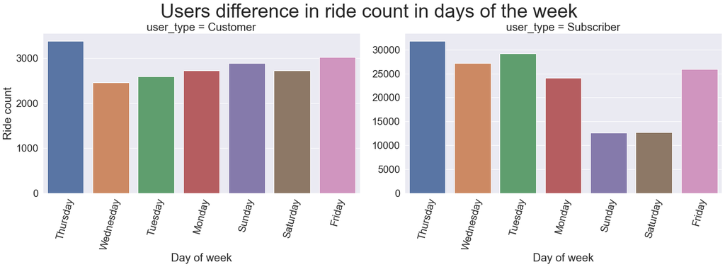

```python
# Use three variables: start_day , count, user_type
sb.set( rc = {'figure.figsize' : ( 30, 20 ),
               'axes.labelsize' : 12 })
sb.set(font_scale = 2)

mv1 = sb.catplot(data=df_clean, x='start_day', col="user_type",
                 kind='count', sharey = False, height=7, aspect=11/7)

mv1.set_xticklabels(rotation=75);

mv1.fig.suptitle("Users difference in ride count in days of the week" ,
               fontsize = 'xx-large')
mv1.fig.subplots_adjust( top = 0.85 )

mv1.set_axis_labels( "Day of week" , "Ride count")


plt.show()
```

As ready to see from the charts over the Sunday and Saturday has the greatest contrast in proportion for customers, Where they have a more indeed proportion with the rest of the weekdays when compared to the subscribers, where their ride rate could be a parcel lower when compared to weekdays. My clarification is that subscribers are commuters who for the most part utilize these bicycles for Monday to Friday for work, and by differentiate, will ride them a part less on Sunday and Saturday. customers are more indeed in their utilization all through the week as they do not utilize them for commuting to work but for recreation.

What is the average trip duration variety on weekdays between customers and subscribers?

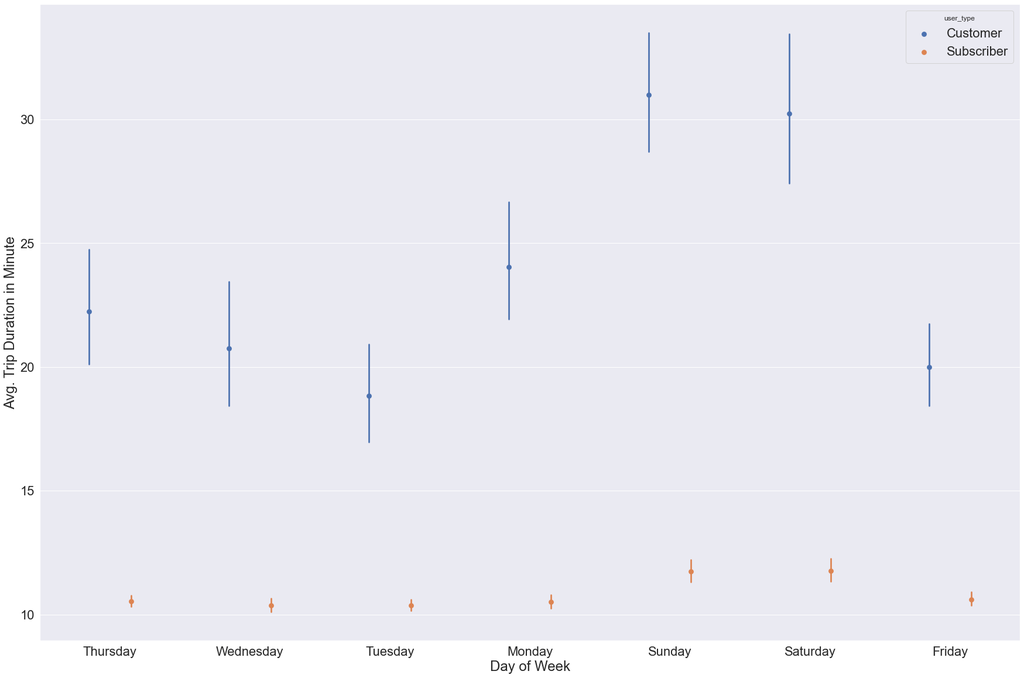

```python
# Use three variables: start_day , duration_min, user_type

sb.pointplot(data=df_clean, x='start_day', y='duration_min', hue='user_type', dodge=0.3, linestyles="");
plt.xlabel('Day of Week');
plt.ylabel('Avg. Trip Duration in Minute');
```

As we can see from the graph above the customer has longest duration trip of subscriber.

### Were there any interesting or surprising interactions between features?

Nothing that surprised.

## Summary

### References:

- https://www.kaggle.com/mohamedahmed10000/ford-gobike-system-data-visualization
- https://github.com/az2a/Udacity-Data-Analyst-Nanodegree/blob/main/Ford_go_bike/Ford_go_bikes.ipynb
- https://www.youtube.com/watch?v=JG8GRlMjp3c